# **Importing Libraries**

```python
# !pip install seaborn
```

```python
# importing required libraries
import numpy as np
import pandas as pd

import pickle # saving and loading trained model
from os import path

# importing required libraries for normalizing data
from sklearn import preprocessing
from sklearn.preprocessing import (StandardScaler, OrdinalEncoder,LabelEncoder, MinMaxScaler, OneHotEncoder)
from sklearn.feature_extraction.text import CountVectorizer
from sklearn.preprocessing import Normalizer, MaxAbsScaler , RobustScaler, PowerTransformer

# importing library for plotting
import matplotlib.pyplot as plt
#plt.rcParams.update({'font.size': 22})

import seaborn as sns
```

## Reading Data

This data set is comprised of **four sub data sets**: **KDDTest+**, **KDDTest-21**, **KDDTrain+**, **KDDTrain+_20Percent**, although **KDDTest-21** and **KDDTrain+_20Percent are subsets of the KDDTrain+ and KDDTest+**. From now on, **KDDTrain+ will be referred to as train** and **KDDTest+ will be referred to as test**. The **KDDTest-21 is a subset of test, without the most difficult traffic records (Score of 21)**, and the **KDDTrain+_20Percent is a subset of train**, whose record count makes up **20% of the entire train dataset**. That being said, the traffic records that exist in the KDDTest-21 and KDDTrain+_20Percent are already in test and train respectively and aren’t new records held out of either dataset.

These data sets contain the **records of the internet traffic** seen by a simple intrusion detection network and are the ghosts of the traffic encountered by a real IDS and just the traces of its existence remains. The data set contains **43 features** per record, with **41 of the features referring to the traffic input** itself and the **last two are labels** (whether it is a normal or attack) and **Score** (the severity of the traffic input itself).

```python
train = 'dataset/KDD_DATA.txt'
```

```python
feature=["duration","protocol_type","service","flag","src_bytes","dst_bytes","land","wrong_fragment","urgent","hot",
          "num_failed_logins","logged_in","num_compromised","root_shell","su_attempted","num_root","num_file_creations","num_shells",
          "num_access_files","num_outbound_cmds","is_host_login","is_guest_login","count","srv_count","serror_rate","srv_serror_rate",
          "rerror_rate","srv_rerror_rate","same_srv_rate","diff_srv_rate","srv_diff_host_rate","dst_host_count","dst_host_srv_count",
          "dst_host_same_srv_rate","dst_host_diff_srv_rate","dst_host_same_src_port_rate","dst_host_srv_diff_host_rate","dst_host_serror_rate",
          "dst_host_srv_serror_rate","dst_host_rerror_rate","dst_host_srv_rerror_rate","label","difficulty"]

flag=['OTH','RSTOS0','SF','SH','RSTO','S2','S1','REJ','S3','RSTR','S0']

protocol_type=['tcp','udp','icmp']

service=['http','smtp','finger','domain_u','auth','telnet','ftp','eco_i','ntp_u','ecr_i','other','private','pop_3','ftp_data',
                  'rje','time','mtp','link','remote_job','gopher','ssh','name','whois','domain','login','imap4','daytime','ctf','nntp',
                  'shell','IRC','nnsp','http_443','exec','printer','efs','courier','uucp','klogin','kshell','echo','discard','systat',
                  'supdup','iso_tsap','hostnames','csnet_ns','pop_2','sunrpc','uucp_path','netbios_ns','netbios_ssn','netbios_dgm',
                  'sql_net','vmnet','bgp','Z39_50','ldap','netstat','urh_i','X11','urp_i','pm_dump','tftp_u','tim_i','red_i','icmp',
                  'http_2784','harvest','aol','http_8001']

binary_attack=['normal','ipsweep', 'nmap', 'portsweep','satan', 'saint', 'mscan','back', 'land', 'neptune', 'pod', 'smurf',
               'teardrop', 'apache2', 'udpstorm', 'processtable','mailbomb','buffer_overflow', 'loadmodule', 'perl', 'rootkit',
               'xterm', 'ps', 'sqlattack','ftp_write', 'guess_passwd', 'imap', 'multihop','phf', 'spy', 'warezclient',
               'warezmaster','snmpgetattack','named', 'xlock', 'xsnoop','sendmail', 'httptunnel', 'worm', 'snmpguess']

multiclass_attack={ 'normal': 'normal',
        'probe': ['ipsweep.', 'nmap.', 'portsweep.','satan.', 'saint.', 'mscan.'],
        'dos': ['back.', 'land.', 'neptune.', 'pod.', 'smurf.','teardrop.', 'apache2.', 'udpstorm.', 'processtable.','mailbomb.'],
        'u2r': ['buffer_overflow.', 'loadmodule.', 'perl.', 'rootkit.','xterm.', 'ps.', 'sqlattack.'],
        'r2l': ['ftp_write.', 'guess_passwd.', 'imap.', 'multihop.','phf.', 'spy.', 'warezclient.', 'warezmaster.','snmpgetattack.',
                   'named.', 'xlock.', 'xsnoop.','sendmail.', 'httptunnel.', 'worm.', 'snmpguess.']}
```

```python
train_data=pd.read_csv(train,names=feature)
```

```python
train_data
```

|  | duration | protocol_type | service | flag | src_bytes | dst_bytes | land | wrong_fragment | urgent | hot | ... | dst_host_same_srv_rate | dst_host_diff_srv_rate | dst_host_same_src_port_rate | dst_host_srv_diff_host_rate | dst_host_serror_rate | dst_host_srv_serror_rate | dst_host_rerror_rate | dst_host_srv_rerror_rate | label | difficulty |
| --- | --- | --- | --- | --- | --- | --- | --- | --- | --- | --- | --- | --- | --- | --- | --- | --- | --- | --- | --- | --- | --- |
| 0 | 0 | tcp | private | REJ | 0 | 0 | 0 | 0 | 0 | 0 | ... | 0.04 | 0.06 | 0.00 | 0.00 | 0.00 | 0.0 | 1.00 | 1.00 | neptune | 21 |
| 1 | 0 | tcp | private | REJ | 0 | 0 | 0 | 0 | 0 | 0 | ... | 0.00 | 0.06 | 0.00 | 0.00 | 0.00 | 0.0 | 1.00 | 1.00 | neptune | 21 |
| 2 | 2 | tcp | ftp_data | SF | 12983 | 0 | 0 | 0 | 0 | 0 | ... | 0.61 | 0.04 | 0.61 | 0.02 | 0.00 | 0.0 | 0.00 | 0.00 | normal | 21 |
| 3 | 0 | icmp | eco_i | SF | 20 | 0 | 0 | 0 | 0 | 0 | ... | 1.00 | 0.00 | 1.00 | 0.28 | 0.00 | 0.0 | 0.00 | 0.00 | saint | 15 |
| 4 | 1 | tcp | telnet | RSTO | 0 | 15 | 0 | 0 | 0 | 0 | ... | 0.31 | 0.17 | 0.03 | 0.02 | 0.00 | 0.0 | 0.83 | 0.71 | mscan | 11 |
| ... | ... | ... | ... | ... | ... | ... | ... | ... | ... | ... | ... | ... | ... | ... | ... | ... | ... | ... | ... | ... | ... |
| 148512 | 0 | tcp | private | S0 | 0 | 0 | 0 | 0 | 0 | 0 | ... | 0.10 | 0.06 | 0.00 | 0.00 | 1.00 | 1.0 | 0.00 | 0.00 | neptune | 20 |
| 148513 | 8 | udp | private | SF | 105 | 145 | 0 | 0 | 0 | 0 | ... | 0.96 | 0.01 | 0.01 | 0.00 | 0.00 | 0.0 | 0.00 | 0.00 | normal | 21 |
| 148514 | 0 | tcp | smtp | SF | 2231 | 384 | 0 | 0 | 0 | 0 | ... | 0.12 | 0.06 | 0.00 | 0.00 | 0.72 | 0.0 | 0.01 | 0.00 | normal | 18 |
| 148515 | 0 | tcp | klogin | S0 | 0 | 0 | 0 | 0 | 0 | 0 | ... | 0.03 | 0.05 | 0.00 | 0.00 | 1.00 | 1.0 | 0.00 | 0.00 | neptune | 20 |
| 148516 | 0 | tcp | ftp_data | SF | 151 | 0 | 0 | 0 | 0 | 0 | ... | 0.30 | 0.03 | 0.30 | 0.00 | 0.00 | 0.0 | 0.00 | 0.00 | normal | 21 |

148517 rows × 43 columns

```python
# remove attribute 'difficulty_level'
train_data.drop(['difficulty'],axis=1,inplace=True)
train_data.shape
```

```
(148517, 42)
```

## Data Type Checking and Statistical Reports

```python
train_data.info()
```

```
<class 'pandas.core.frame.DataFrame'>
RangeIndex: 148517 entries, 0 to 148516
Data columns (total 42 columns):
duration                       148517 non-null int64
protocol_type                  148517 non-null object
service                        148517 non-null object
flag                           148517 non-null object
src_bytes                      148517 non-null int64
dst_bytes                      148517 non-null int64
land                           148517 non-null int64
wrong_fragment                 148517 non-null int64
urgent                         148517 non-null int64
hot                            148517 non-null int64
num_failed_logins              148517 non-null int64
logged_in                      148517 non-null int64
num_compromised                148517 non-null int64
root_shell                     148517 non-null int64
su_attempted                   148517 non-null int64
num_root                       148517 non-null int64
num_file_creations             148517 non-null int64
num_shells                     148517 non-null int64
num_access_files               148517 non-null int64
num_outbound_cmds              148517 non-null int64
is_host_login                  148517 non-null int64
is_guest_login                 148517 non-null int64
count                          148517 non-null int64
srv_count                      148517 non-null int64
serror_rate                    148517 non-null float64
srv_serror_rate                148517 non-null float64
rerror_rate                    148517 non-null float64
srv_rerror_rate                148517 non-null float64
same_srv_rate                  148517 non-null float64
diff_srv_rate                  148517 non-null float64
srv_diff_host_rate             148517 non-null float64
dst_host_count                 148517 non-null int64
dst_host_srv_count             148517 non-null int64
dst_host_same_srv_rate         148517 non-null float64
dst_host_diff_srv_rate         148517 non-null float64
dst_host_same_src_port_rate    148517 non-null float64
dst_host_srv_diff_host_rate    148517 non-null float64
dst_host_serror_rate           148517 non-null float64
dst_host_srv_serror_rate       148517 non-null float64
dst_host_rerror_rate           148517 non-null float64
dst_host_srv_rerror_rate       148517 non-null float64
label                          148517 non-null object
dtypes: float64(15), int64(23), object(4)
memory usage: 47.6+ MB
```

```python
train_data.describe().T
```

|  | count | mean | std | min | 25% | 50% | 75% | max |
| --- | --- | --- | --- | --- | --- | --- | --- | --- |
| duration | 148517.0 | 276.779305 | 2.460683e+03 | 0.0 | 0.00 | 0.00 | 0.00 | 5.771500e+04 |
| src_bytes | 148517.0 | 40227.949299 | 5.409612e+06 | 0.0 | 0.00 | 44.00 | 278.00 | 1.379964e+09 |
| dst_bytes | 148517.0 | 17088.853593 | 3.703525e+06 | 0.0 | 0.00 | 0.00 | 571.00 | 1.309937e+09 |
| land | 148517.0 | 0.000215 | 1.467714e-02 | 0.0 | 0.00 | 0.00 | 0.00 | 1.000000e+00 |
| wrong_fragment | 148517.0 | 0.020523 | 2.400691e-01 | 0.0 | 0.00 | 0.00 | 0.00 | 3.000000e+00 |
| urgent | 148517.0 | 0.000202 | 1.941708e-02 | 0.0 | 0.00 | 0.00 | 0.00 | 3.000000e+00 |
| hot | 148517.0 | 0.189379 | 2.013160e+00 | 0.0 | 0.00 | 0.00 | 0.00 | 1.010000e+02 |
| num_failed_logins | 148517.0 | 0.004323 | 7.224823e-02 | 0.0 | 0.00 | 0.00 | 0.00 | 5.000000e+00 |
| logged_in | 148517.0 | 0.402789 | 4.904606e-01 | 0.0 | 0.00 | 0.00 | 1.00 | 1.000000e+00 |
| num_compromised | 148517.0 | 0.255062 | 2.223137e+01 | 0.0 | 0.00 | 0.00 | 0.00 | 7.479000e+03 |
| root_shell | 148517.0 | 0.001508 | 3.880696e-02 | 0.0 | 0.00 | 0.00 | 0.00 | 1.000000e+00 |
| su_attempted | 148517.0 | 0.000976 | 4.238907e-02 | 0.0 | 0.00 | 0.00 | 0.00 | 2.000000e+00 |
| num_root | 148517.0 | 0.273726 | 2.268902e+01 | 0.0 | 0.00 | 0.00 | 0.00 | 7.468000e+03 |
| num_file_creations | 148517.0 | 0.012073 | 5.178631e-01 | 0.0 | 0.00 | 0.00 | 0.00 | 1.000000e+02 |
| num_shells | 148517.0 | 0.000525 | 2.770051e-02 | 0.0 | 0.00 | 0.00 | 0.00 | 5.000000e+00 |
| num_access_files | 148517.0 | 0.004013 | 9.525663e-02 | 0.0 | 0.00 | 0.00 | 0.00 | 9.000000e+00 |
| num_outbound_cmds | 148517.0 | 0.000000 | 0.000000e+00 | 0.0 | 0.00 | 0.00 | 0.00 | 0.000000e+00 |
| is_host_login | 148517.0 | 0.000081 | 8.988484e-03 | 0.0 | 0.00 | 0.00 | 0.00 | 1.000000e+00 |
| is_guest_login | 148517.0 | 0.012308 | 1.102585e-01 | 0.0 | 0.00 | 0.00 | 0.00 | 1.000000e+00 |
| count | 148517.0 | 83.336561 | 1.167607e+02 | 0.0 | 2.00 | 13.00 | 141.00 | 5.110000e+02 |
| srv_count | 148517.0 | 28.251937 | 7.536963e+01 | 0.0 | 2.00 | 7.00 | 17.00 | 5.110000e+02 |
| serror_rate | 148517.0 | 0.256925 | 4.319178e-01 | 0.0 | 0.00 | 0.00 | 0.85 | 1.000000e+00 |
| srv_serror_rate | 148517.0 | 0.255337 | 4.325783e-01 | 0.0 | 0.00 | 0.00 | 0.91 | 1.000000e+00 |
| rerror_rate | 148517.0 | 0.137947 | 3.393872e-01 | 0.0 | 0.00 | 0.00 | 0.00 | 1.000000e+00 |
| srv_rerror_rate | 148517.0 | 0.138487 | 3.417829e-01 | 0.0 | 0.00 | 0.00 | 0.00 | 1.000000e+00 |
| same_srv_rate | 148517.0 | 0.672983 | 4.365437e-01 | 0.0 | 0.10 | 1.00 | 1.00 | 1.000000e+00 |
| diff_srv_rate | 148517.0 | 0.067761 | 1.946658e-01 | 0.0 | 0.00 | 0.00 | 0.06 | 1.000000e+00 |
| srv_diff_host_rate | 148517.0 | 0.097441 | 2.588856e-01 | 0.0 | 0.00 | 0.00 | 0.00 | 1.000000e+00 |
| dst_host_count | 148517.0 | 183.928042 | 9.852833e+01 | 0.0 | 87.00 | 255.00 | 255.00 | 2.550000e+02 |
| dst_host_srv_count | 148517.0 | 119.462661 | 1.112323e+02 | 0.0 | 11.00 | 72.00 | 255.00 | 2.550000e+02 |
| dst_host_same_srv_rate | 148517.0 | 0.534521 | 4.480612e-01 | 0.0 | 0.05 | 0.60 | 1.00 | 1.000000e+00 |
| dst_host_diff_srv_rate | 148517.0 | 0.084103 | 1.941020e-01 | 0.0 | 0.00 | 0.02 | 0.07 | 1.000000e+00 |
| dst_host_same_src_port_rate | 148517.0 | 0.145932 | 3.086376e-01 | 0.0 | 0.00 | 0.00 | 0.05 | 1.000000e+00 |
| dst_host_srv_diff_host_rate | 148517.0 | 0.030584 | 1.089751e-01 | 0.0 | 0.00 | 0.00 | 0.01 | 1.000000e+00 |
| dst_host_serror_rate | 148517.0 | 0.256122 | 4.284996e-01 | 0.0 | 0.00 | 0.00 | 0.60 | 1.000000e+00 |
| dst_host_srv_serror_rate | 148517.0 | 0.251304 | 4.297194e-01 | 0.0 | 0.00 | 0.00 | 0.50 | 1.000000e+00 |
| dst_host_rerror_rate | 148517.0 | 0.136220 | 3.227411e-01 | 0.0 | 0.00 | 0.00 | 0.00 | 1.000000e+00 |
| dst_host_srv_rerror_rate | 148517.0 | 0.136397 | 3.352823e-01 | 0.0 | 0.00 | 0.00 | 0.00 | 1.000000e+00 |

```python
# number of attack labels
train_data['label'].value_counts()
```

```
normal             77054
neptune            45871
satan               4368
ipsweep             3740
smurf               3311
portsweep           3088
nmap                1566
back                1315
guess_passwd        1284
mscan                996
warezmaster          964
teardrop             904
warezclient          890
apache2              737
processtable         685
snmpguess            331
saint                319
mailbomb             293
pod                  242
snmpgetattack        178
httptunnel           133
buffer_overflow       50
multihop              25
land                  25
rootkit               23
named                 17
ps                    15
sendmail              14
xterm                 13
imap                  12
ftp_write             11
loadmodule            11
xlock                  9
phf                    6
perl                   5
xsnoop                 4
spy                    2
sqlattack              2
udpstorm               2
worm                   2
Name: label, dtype: int64
```

[output not shown]

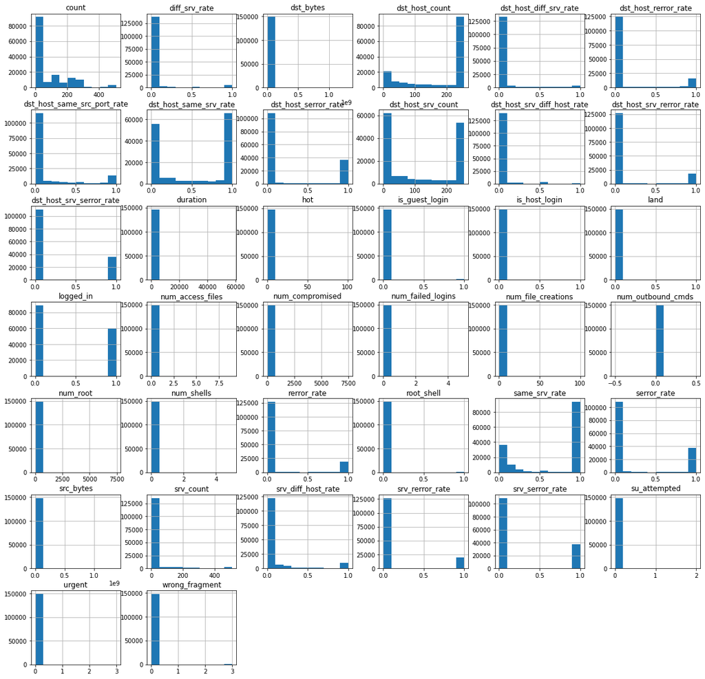

```python
plt.rcParams['figure.figsize'] = (20, 20)

train_data.hist()
```

# **Data Analysis**

- Data Visualization
- Data Mining

## **Univariate Analysis**

```python
def bar_graph(feature):
  train_data[feature].value_counts().plot(kind="bar")
```

### Label

```python
# number of attack labels
train_data['label'].value_counts()
```

```
normal             77054
neptune            45871
satan               4368
ipsweep             3740
smurf               3311
portsweep           3088
nmap                1566
back                1315
guess_passwd        1284
mscan                996
warezmaster          964
teardrop             904
warezclient          890
apache2              737
processtable         685
snmpguess            331
saint                319
mailbomb             293
pod                  242
snmpgetattack        178
httptunnel           133
buffer_overflow       50
multihop              25
land                  25
rootkit               23
named                 17
ps                    15
sendmail              14
xterm                 13
imap                  12
ftp_write             11
loadmodule            11
xlock                  9
phf                    6
perl                   5
xsnoop                 4
spy                    2
sqlattack              2
udpstorm               2
worm                   2
Name: label, dtype: int64
```

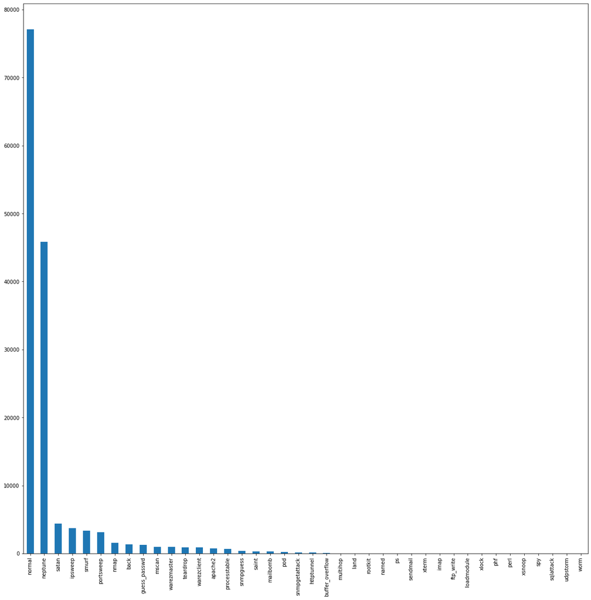

```python
bar_graph('label')
```

Within the data set exists **4 different classes of attacks**:

- **Denial of Service (DoS)**
- **Probe**
- **User to Root(U2R)**
- **Remote to Local (R2L)**

**DoS** is an attack that **tries to shut down traffic flow** to and from the target system. **The IDS is flooded with an abnormal amount of traffic**, which the **system can’t handle**, and **shuts down to protect itself**. This prevents normal traffic from visiting a network. An example of this could be an online retailer getting flooded with online orders on a day with a big sale, and because the network can’t handle all the requests, it will shut down preventing paying customers to purchase anything. **This is the most common attack in the data set**.

**Probe** or surveillance is an attack that **tries to get information from a network**. The goal here is to act like a thief and **steal important information**, whether it be personal information about clients or banking information.

**U2R** is an attack that **starts off with a normal user account** and **tries to gain access to the system or network, as a super-user (root)**. The attacker attempts to exploit the vulnerabilities in a system to **gain root privileges/access**.

**R2L** is an attack that tries to **gain local access to a remote machine**. **An attacker does not have local access to the system/network**, and tries to “hack” their way into the network.

It is noticed from the descriptions above that **DoS acts differently from the other three attacks**, where **DoS attempts to shut down a system to stop traffic flow altogether**, whereas the **other three attempts to quietly infiltrate the system undetected**.

In the table below, a breakdown of the **different subclasses of each attack** that exists in the data set is shown:

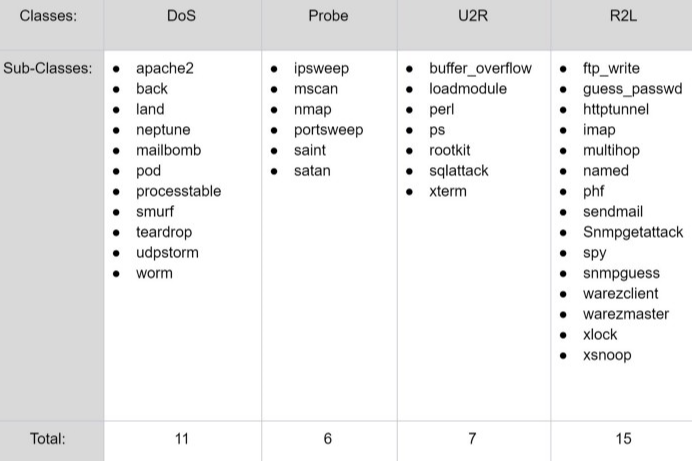

```python
# changing attack labels to their respective attack class
def change_label(df):
  df.label.replace(['apache2','back','land','neptune','mailbomb','pod','processtable','smurf','teardrop','udpstorm','worm'],'Dos',inplace=True)
  df.label.replace(['ftp_write','guess_passwd','httptunnel','imap','multihop','named','phf','sendmail','snmpgetattack','snmpguess','spy','warezclient','warezmaster','xlock','xsnoop'],'R2L',inplace=True)
  df.label.replace(['ipsweep','mscan','nmap','portsweep','saint','satan'],'Probe',inplace=True)
  df.label.replace(['buffer_overflow','loadmodule','perl','ps','rootkit','sqlattack','xterm'],'U2R',inplace=True)
```

```python
change_label(train_data)
```

```python
# distribution of attack classes
train_data.label.value_counts()
```

```
normal    77054
Dos       53387
Probe     14077
R2L        3880
U2R         119
Name: label, dtype: int64
```

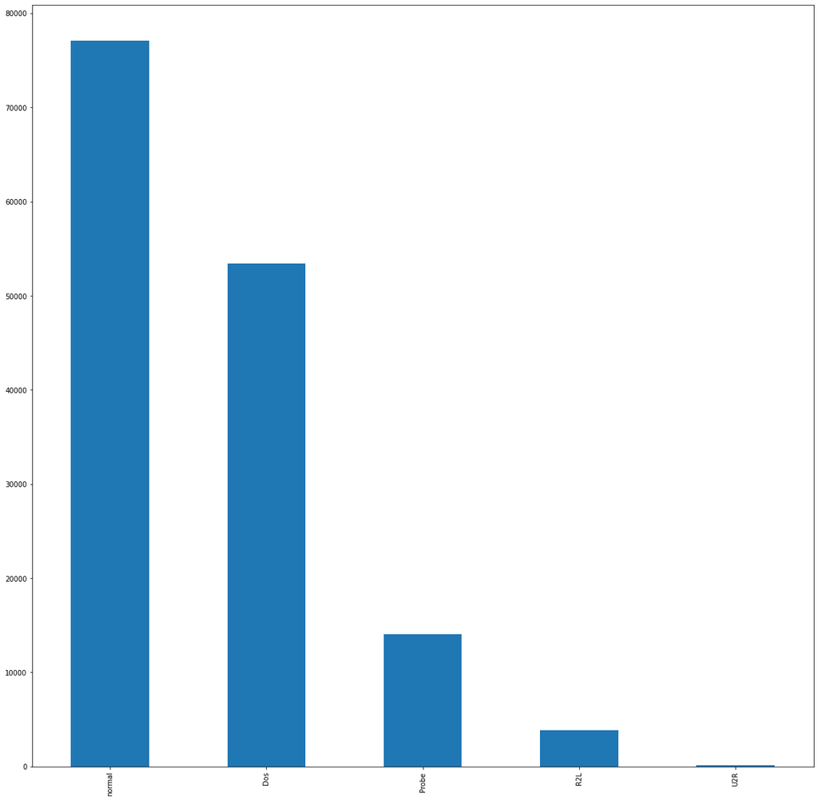

```python
bar_graph('label')
```

```python
# distribution of attack classes
train_data.label.value_counts()
```

```
normal    77054
Dos       53387
Probe     14077
R2L        3880
U2R         119
Name: label, dtype: int64
```

### Protocol

- **Attribute No.** : 2
- **Attribute Name.** : Protocol_type
- **Description** : Protocol used in the connection

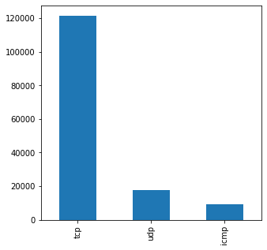

```python
plt.rcParams['figure.figsize'] = (5, 5)
bar_graph('protocol_type')
```

### Services

- **Attribute No.** : 3
- **Attribute Name.** : Service
- **Description** : Destination network service used

```python
services_frequency = train_data['service'].value_counts()
subsetServices= list(services_frequency[:30].index)
services_frequency
```

```
http         48191
private      26627
domain_u      9937
smtp          8247
ftp_data      7711
             ...
tftp_u           4
aol              2
harvest          2
http_8001        2
http_2784        1
Name: service, Length: 70, dtype: int64
```

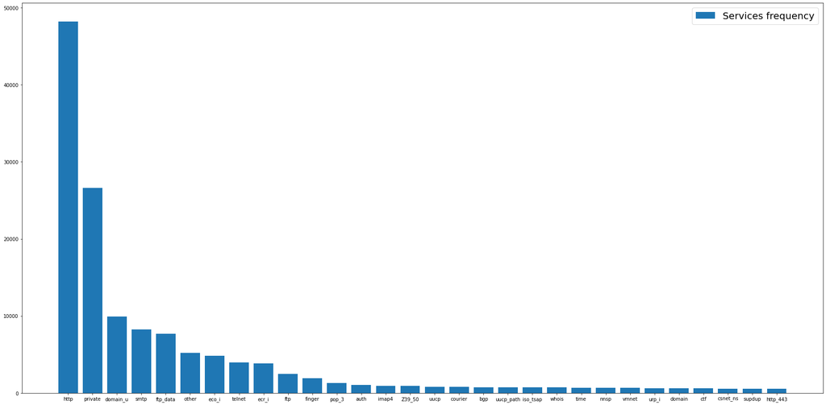

```python
import matplotlib.pyplot as plt

f, ax = plt.subplots(figsize=(30,15)) # set the size that you'd like (width, height)
plt.bar(subsetServices, services_frequency[:30], label = 'Services frequency')
ax.legend(fontsize = 20)
```

### Duration

- **Attribute No.** : 1
- **Attribute Name.** : Duration
- **Description** : Length of time duration of the connection

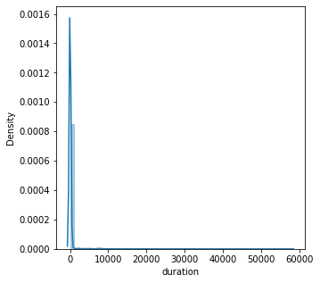

```python
import seaborn as sns
df = train_data['duration']
df = pd.DataFrame(df)
data_feature = df.columns

for feature in data_feature:
    p = sns.distplot(a = df[feature])
    plt.show()
```

```python
df['binned']=pd.cut(df['duration'], bins=[-0.1, 0 , 10000, 20000, 30000, 40000])
df.head()
```

|  | duration | binned |
| --- | --- | --- |
| 0 | 0 | (-0.1, 0.0] |
| 1 | 0 | (-0.1, 0.0] |
| 2 | 2 | (0.0, 10000.0] |
| 3 | 0 | (-0.1, 0.0] |
| 4 | 1 | (0.0, 10000.0] |

```python
df['duration_bin']=pd.cut(df['duration'], bins=[-0.1, 0 , 10000, 20000, 30000, 40000], labels=["0", " (0, 10000]", "(10000, 20000]","(20000, 30000]", "(30000, 40000]"])
df
```

|  | duration | binned | duration_bin |
| --- | --- | --- | --- |
| 0 | 0 | (-0.1, 0.0] | 0 |
| 1 | 0 | (-0.1, 0.0] | 0 |
| 2 | 2 | (0.0, 10000.0] | (0, 10000] |
| 3 | 0 | (-0.1, 0.0] | 0 |
| 4 | 1 | (0.0, 10000.0] | (0, 10000] |
| ... | ... | ... | ... |
| 148512 | 0 | (-0.1, 0.0] | 0 |
| 148513 | 8 | (0.0, 10000.0] | (0, 10000] |
| 148514 | 0 | (-0.1, 0.0] | 0 |
| 148515 | 0 | (-0.1, 0.0] | 0 |
| 148516 | 0 | (-0.1, 0.0] | 0 |

148517 rows × 3 columns

```python
duration_frequency = df['duration_bin'].value_counts()
#subsetServices= list(duration_frequency[:].index)
duration_frequency
```

```
0                 134973
 (0, 10000]        12316
(10000, 20000]       591
(30000, 40000]       282
(20000, 30000]       225
Name: duration_bin, dtype: int64
```

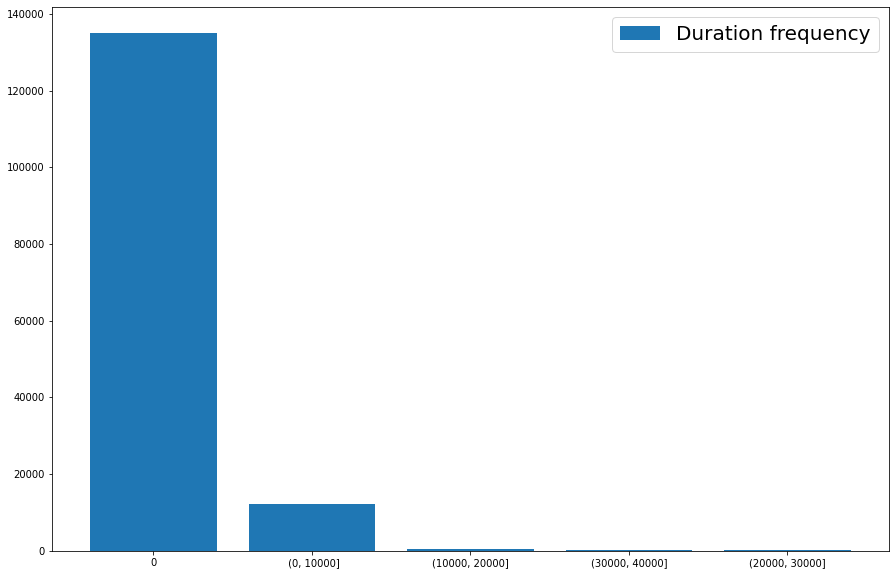

```python
f, ax = plt.subplots(figsize=(15,10)) # set the size that you'd like (width, height)
plt.bar(duration_frequency.index, duration_frequency, label = 'Duration frequency')
ax.legend(fontsize = 20)
```

### Flag

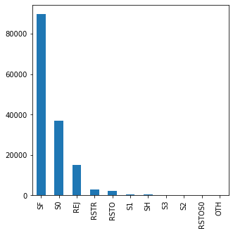

```python
bar_graph('flag')
```

## **Bivariate Analysis**

### Protocol, Attack Types

```python
df= pd.DataFrame(columns=['protocol', 'Attack_class', 'number of sample in Dataset'])
```

```python
protocols = pd.Series(train_data['protocol_type']).unique()
Label = pd.Series(train_data['label']).unique()
Label= np.delete(Label, np.where(Label == 'normal'))
```

```python
for pro in protocols:
  for lab in Label:
    i = len(train_data.loc[(train_data['protocol_type']== pro) & (train_data['label']==lab)])
    if (i != 0):
      df= df.append({'protocol': pro, 'Attack_class': lab, 'number of sample in Dataset': i}, ignore_index=True)
```

```python
df.sort_values(by=['number of sample in Dataset'], ascending=False)
```

|  | protocol | Attack_class | number of sample in Dataset |
| --- | --- | --- | --- |
| 0 | tcp | Dos | 48928 |
| 1 | tcp | Probe | 7721 |
| 5 | icmp | Probe | 4375 |
| 4 | icmp | Dos | 3553 |
| 2 | tcp | R2L | 3362 |
| 8 | udp | Probe | 1981 |
| 7 | udp | Dos | 906 |
| 9 | udp | R2L | 514 |
| 3 | tcp | U2R | 116 |
| 6 | icmp | R2L | 4 |
| 10 | udp | U2R | 3 |

### Service, Attack Types

```python
df_service= pd.DataFrame(columns=['service', 'Attack_class', 'number of sample in Dataset'])
```

```python
services = list(services_frequency.index)
Label = pd.Series(train_data['label']).unique()
Label= np.delete(Label, np.where(Label == 'normal'))
```

```python
for ser in services:
  for lab in Label:
    i = len(train_data.loc[(train_data['service']== ser) & (train_data['label']==lab)])
    if (i != 0):
      df_service= df_service.append({'service': ser, 'Attack_class': lab, 'number of sample in Dataset': i}, ignore_index=True)
```

```python
df_service.sort_values(by=['number of sample in Dataset'], ascending=False)
```

|  | service | Attack_class | number of sample in Dataset |
| --- | --- | --- | --- |
| 3 | private | Dos | 18877 |
| 4 | private | Probe | 5418 |
| 18 | eco_i | Probe | 4325 |
| 23 | ecr_i | Dos | 3545 |
| 0 | http | Dos | 3430 |
| ... | ... | ... | ... |
| 136 | aol | Probe | 2 |
| 137 | harvest | Probe | 2 |
| 138 | http_8001 | Probe | 2 |
| 121 | IRC | R2L | 1 |
| 139 | http_2784 | Probe | 1 |

140 rows × 3 columns

## **Multivariate Analysis**

### Protocol Type, Services, Label

```python
df= pd.DataFrame(columns=['protocol', 'service', 'label', 'number of sample in Dataset'])
```

```python
services = list(services_frequency.index)
protocols = pd.Series(train_data['protocol_type']).unique()
Label = pd.Series(train_data['label']).unique()

for ser in services:
  for pro in protocols:
    for lab in Label:
      i = len(train_data.loc[(train_data['service']== ser) & (train_data['protocol_type']== pro) & (train_data['label']==lab)])
      if (i != 0):
        df= df.append({'protocol': pro, 'service': ser, 'label': lab, 'number of sample in Dataset': i}, ignore_index=True)
```

```python
df.sort_values(by=['number of sample in Dataset'], ascending=False)
```

|  | protocol | service | label | number of sample in Dataset |
| --- | --- | --- | --- | --- |
| 1 | tcp | http | normal | 44722 |
| 4 | tcp | private | Dos | 17971 |
| 11 | udp | domain_u | normal | 9926 |
| 14 | tcp | smtp | normal | 7647 |
| 18 | tcp | ftp_data | normal | 5304 |
| ... | ... | ... | ... | ... |
| 171 | tcp | harvest | Probe | 2 |
| 152 | tcp | remote_job | normal | 1 |
| 147 | tcp | IRC | R2L | 1 |
| 107 | tcp | link | normal | 1 |
| 173 | tcp | http_2784 | Probe | 1 |

174 rows × 4 columns

# **Data Prepration**

```python
train_data
```

|  | duration | protocol_type | service | flag | src_bytes | dst_bytes | land | wrong_fragment | urgent | hot | ... | dst_host_srv_count | dst_host_same_srv_rate | dst_host_diff_srv_rate | dst_host_same_src_port_rate | dst_host_srv_diff_host_rate | dst_host_serror_rate | dst_host_srv_serror_rate | dst_host_rerror_rate | dst_host_srv_rerror_rate | label |
| --- | --- | --- | --- | --- | --- | --- | --- | --- | --- | --- | --- | --- | --- | --- | --- | --- | --- | --- | --- | --- | --- |
| 0 | 0 | tcp | private | REJ | 0 | 0 | 0 | 0 | 0 | 0 | ... | 10 | 0.04 | 0.06 | 0.00 | 0.00 | 0.00 | 0.0 | 1.00 | 1.00 | Dos |
| 1 | 0 | tcp | private | REJ | 0 | 0 | 0 | 0 | 0 | 0 | ... | 1 | 0.00 | 0.06 | 0.00 | 0.00 | 0.00 | 0.0 | 1.00 | 1.00 | Dos |
| 2 | 2 | tcp | ftp_data | SF | 12983 | 0 | 0 | 0 | 0 | 0 | ... | 86 | 0.61 | 0.04 | 0.61 | 0.02 | 0.00 | 0.0 | 0.00 | 0.00 | normal |
| 3 | 0 | icmp | eco_i | SF | 20 | 0 | 0 | 0 | 0 | 0 | ... | 57 | 1.00 | 0.00 | 1.00 | 0.28 | 0.00 | 0.0 | 0.00 | 0.00 | Probe |
| 4 | 1 | tcp | telnet | RSTO | 0 | 15 | 0 | 0 | 0 | 0 | ... | 86 | 0.31 | 0.17 | 0.03 | 0.02 | 0.00 | 0.0 | 0.83 | 0.71 | Probe |
| ... | ... | ... | ... | ... | ... | ... | ... | ... | ... | ... | ... | ... | ... | ... | ... | ... | ... | ... | ... | ... | ... |
| 148512 | 0 | tcp | private | S0 | 0 | 0 | 0 | 0 | 0 | 0 | ... | 25 | 0.10 | 0.06 | 0.00 | 0.00 | 1.00 | 1.0 | 0.00 | 0.00 | Dos |
| 148513 | 8 | udp | private | SF | 105 | 145 | 0 | 0 | 0 | 0 | ... | 244 | 0.96 | 0.01 | 0.01 | 0.00 | 0.00 | 0.0 | 0.00 | 0.00 | normal |
| 148514 | 0 | tcp | smtp | SF | 2231 | 384 | 0 | 0 | 0 | 0 | ... | 30 | 0.12 | 0.06 | 0.00 | 0.00 | 0.72 | 0.0 | 0.01 | 0.00 | normal |
| 148515 | 0 | tcp | klogin | S0 | 0 | 0 | 0 | 0 | 0 | 0 | ... | 8 | 0.03 | 0.05 | 0.00 | 0.00 | 1.00 | 1.0 | 0.00 | 0.00 | Dos |
| 148516 | 0 | tcp | ftp_data | SF | 151 | 0 | 0 | 0 | 0 | 0 | ... | 77 | 0.30 | 0.03 | 0.30 | 0.00 | 0.00 | 0.0 | 0.00 | 0.00 | normal |

148517 rows × 42 columns

```python
for i in train_data.columns:
    print('\n',i)
    print(train_data[i].unique())
```

```
 duration
[    0     2     1 ...  5430 11680   679]

 protocol_type
['tcp' 'icmp' 'udp']

 service
['private' 'ftp_data' 'eco_i' 'telnet' 'http' 'smtp' 'ftp' 'ldap' 'pop_3'
 'courier' 'discard' 'ecr_i' 'imap4' 'domain_u' 'mtp' 'systat' 'iso_tsap'
 'other' 'csnet_ns' 'finger' 'uucp' 'whois' 'netbios_ns' 'link' 'Z39_50'
 'sunrpc' 'auth' 'netbios_dgm' 'uucp_path' 'vmnet' 'domain' 'name' 'pop_2'
 'http_443' 'urp_i' 'login' 'gopher' 'exec' 'time' 'remote_job' 'ssh'
 'kshell' 'sql_net' 'shell' 'hostnames' 'echo' 'daytime' 'pm_dump' 'IRC'
 'netstat' 'ctf' 'nntp' 'netbios_ssn' 'tim_i' 'supdup' 'bgp' 'nnsp' 'rje'
 'printer' 'efs' 'X11' 'ntp_u' 'klogin' 'tftp_u' 'red_i' 'urh_i'
 'http_8001' 'aol' 'http_2784' 'harvest']

 flag
['REJ' 'SF' 'RSTO' 'S0' 'RSTR' 'SH' 'S3' 'S2' 'S1' 'RSTOS0' 'OTH']

 src_bytes
[    0 12983    20 ...  2816 11466  2358]

 dst_bytes
[    0    15 14515 ...  5424 17655 52866]

 land
[0 1]

 wrong_fragment
[0 1 3]

 urgent
[0 1 2 3]

 hot
[  0   4   2   1   7   6   5   3  22  10  11  19 101  18  15  30  28  24
  14  25  77  17  20  12   9   8  21  33  44]

 num_failed_logins
```

[output cut: 275 more lines]

```
 0.5  0.64 0.55 0.26 0.58 0.37 0.27 0.48 0.93 0.52 0.46 0.15 0.21 0.59
 0.75 0.28 0.54]

 dst_host_srv_rerror_rate
[1.   0.   0.71 0.04 0.02 0.32 0.07 0.95 0.06 0.67 0.01 0.19 0.98 0.22
 0.18 0.03 0.7  0.49 0.68 0.16 0.31 0.43 0.97 0.59 0.51 0.05 0.08 0.77
 0.75 0.69 0.48 0.37 0.17 0.35 0.96 0.23 0.53 0.25 0.3  0.27 0.65 0.66
 0.44 0.56 0.41 0.12 0.62 0.14 0.2  0.6  0.72 0.36 0.54 0.4  0.1  0.94
 0.84 0.15 0.82 0.91 0.13 0.64 0.46 0.73 0.58 0.88 0.63 0.11 0.47 0.89
 0.8  0.93 0.09 0.5  0.33 0.61 0.24 0.81 0.74 0.28 0.39 0.57 0.9  0.42
 0.29 0.34 0.26 0.86 0.55 0.83 0.92 0.38 0.21 0.76 0.87 0.52 0.45 0.78
 0.85 0.79 0.99]

 label
['Dos' 'normal' 'Probe' 'R2L' 'U2R']
```

```python
train_data.duration.unique()
```

```
array([    0,     2,     1, ...,  5430, 11680,   679], dtype=int64)
```

```python
train_data.columns
```

```
Index(['duration', 'protocol_type', 'service', 'flag', 'src_bytes',
       'dst_bytes', 'land', 'wrong_fragment', 'urgent', 'hot',
       'num_failed_logins', 'logged_in', 'num_compromised', 'root_shell',
       'su_attempted', 'num_root', 'num_file_creations', 'num_shells',
       'num_access_files', 'num_outbound_cmds', 'is_host_login',
       'is_guest_login', 'count', 'srv_count', 'serror_rate',
       'srv_serror_rate', 'rerror_rate', 'srv_rerror_rate', 'same_srv_rate',
       'diff_srv_rate', 'srv_diff_host_rate', 'dst_host_count',
       'dst_host_srv_count', 'dst_host_same_srv_rate',
       'dst_host_diff_srv_rate', 'dst_host_same_src_port_rate',
       'dst_host_srv_diff_host_rate', 'dst_host_serror_rate',
       'dst_host_srv_serror_rate', 'dst_host_rerror_rate',
       'dst_host_srv_rerror_rate', 'label'],
      dtype='object')
```

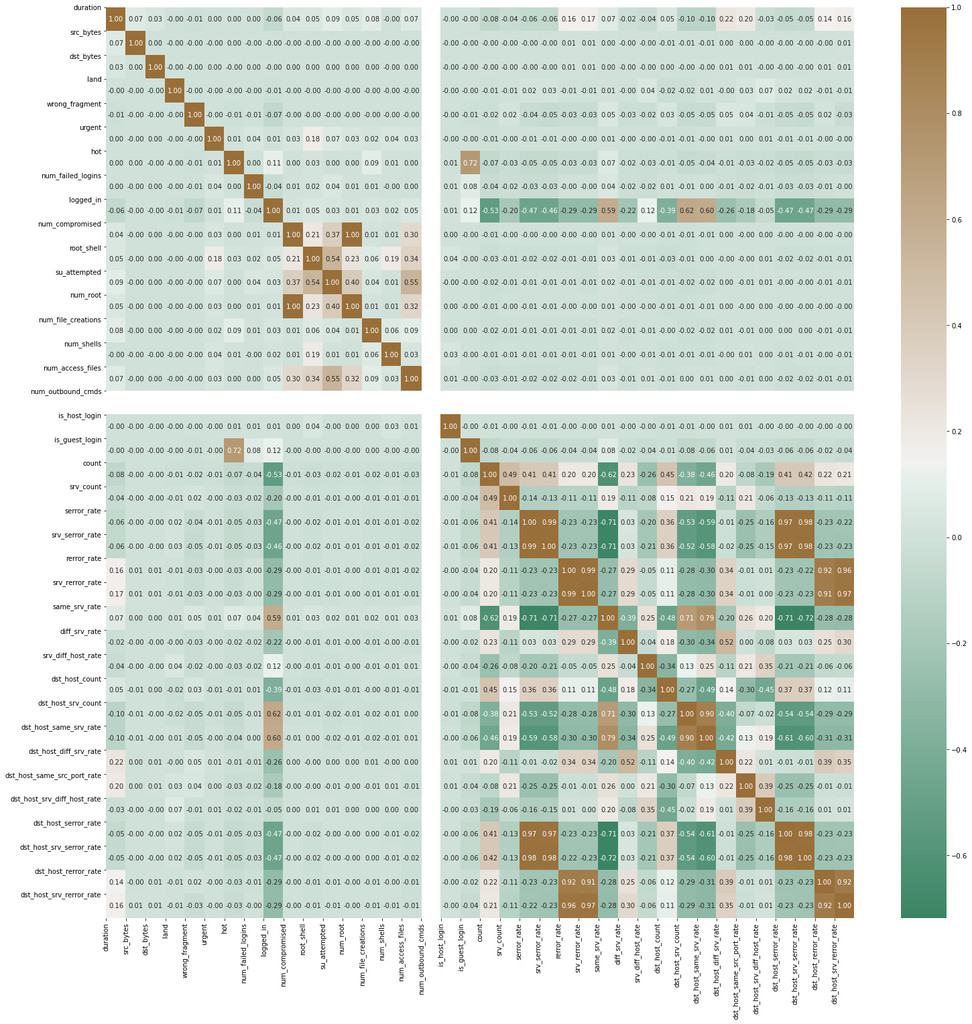

```python
## Plotting Correlation of columns
corr = train_data.corr()
fig, ax = plt.subplots(figsize=(25, 25))
colormap = sns.diverging_palette(150,50, as_cmap=True)
sns.heatmap(corr, cmap=colormap, annot=True, fmt=".2f")
plt.xticks(range(len(corr.columns)), corr.columns);
plt.yticks(range(len(corr.columns)), corr.columns)
plt.show()
```